# Sahadeo_Assignment5-3

Rishi Sahadeo

2025-10-03

```r
# load data set
brewing <- read.table("C:/Users/supaq/OneDrive/Desktop/Rutgers Courses/Regression Methods - Fall 2025/brewing_data.txt", header = TRUE, sep = "\t")

dim(brewing)
```

```
## [1] 200   2
```

```r
head(brewing, 5)
```

```
##   Temperature Alcohol_Percentage
## 1    57.10730           6.408689
## 2    65.18005           2.767534
## 3    60.84602           4.216626
## 4    61.60914           4.332007
## 5    62.83093           3.548368
```

### 1) Visually display the data in an appropriate graph and comment on anything that may be of note. In particular, are the assumptions needed for fitting the simple linear model met?

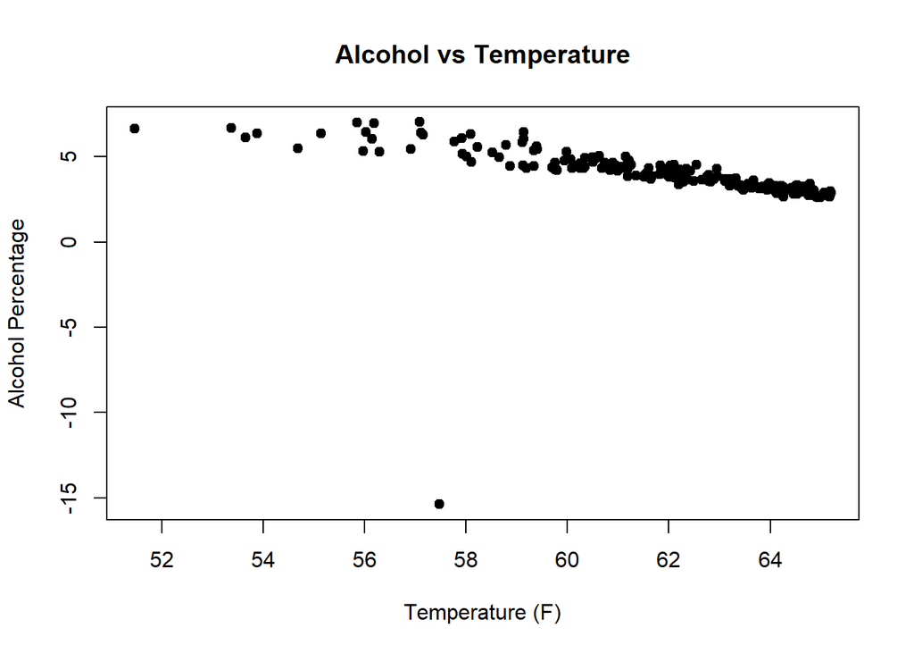

```r
plot(brewing$Temperature, brewing$Alcohol_Percentage,
     xlab = "Temperature (F)",
     ylab = "Alcohol Percentage",
     main = "Alcohol vs Temperature",
     pch = 19)
```

### 2) Initially, the brewer would just like to get a rough estimate of what the alcohol content would be if he ferments the batch at a given temperature. Are enough of the regression assumptions satisfied so that simple linear regression can be used towards the prior-mentioned goal? If not, what deviations do you need to address and how do you address them?

```r
which(brewing$Alcohol_Percentage < 0)
```

```
## [1] 186
```

```r
brewing_clean <- subset(brewing, Alcohol_Percentage >= 0)
dim(brewing);
```

```
## [1] 200   2
```

```r
dim(brewing_clean)
```

```
## [1] 199   2
```

For the brewer’s goal of obtaining a rough estimate of alcohol content at a given temperature, the assumptions of a simple linear regression are reasonably well met after addressing one clear violation. The scatterplot showed a negative alcohol percentage value at observation 186. Since alcohol content cannot be negative, this is a data entry or measurement error and was excluded from the analysis.

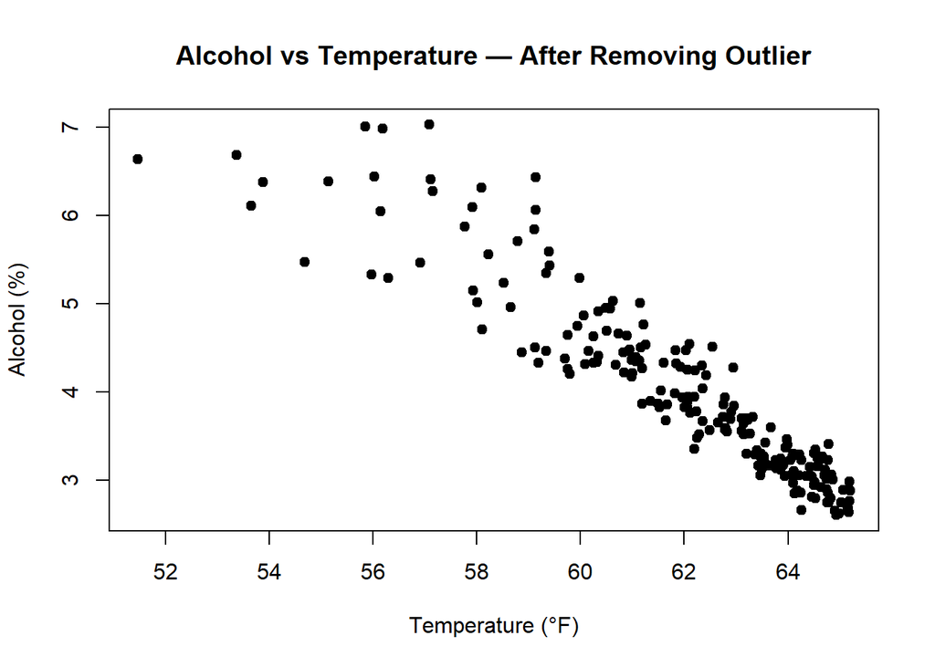

```r
plot(brewing_clean$Temperature, brewing_clean$Alcohol_Percentage,
     xlab = "Temperature (°F)",
    ylab = "Alcohol (%)",
     main = "Alcohol vs Temperature — After Removing Outlier",
     pch = 19)
```

### 3) After addressing any necessary issues in part 2, fit the simple linear model to the data. Provide the parameter estimates and the R2 value.

```r
brew_fit <- lm(Alcohol_Percentage ~ Temperature, data = brewing_clean)
brew_fit
```

```
##
## Call:
## lm(formula = Alcohol_Percentage ~ Temperature, data = brewing_clean)
##
## Coefficients:
## (Intercept)  Temperature
##      26.174       -0.358
```

```r
summary(brew_fit)
```

```
##
## Call:
## lm(formula = Alcohol_Percentage ~ Temperature, data = brewing_clean)
##
## Residuals:
##      Min       1Q   Median       3Q      Max
## -1.12419 -0.21920 -0.05328  0.19142  1.42246
##
## Coefficients:
##              Estimate Std. Error t value Pr(>|t|)
## (Intercept) 26.173742   0.613251   42.68   <2e-16 ***
## Temperature -0.357968   0.009907  -36.13   <2e-16 ***
## ---
## Signif. codes:  0 '***' 0.001 '**' 0.01 '*' 0.05 '.' 0.1 ' ' 1
##
## Residual standard error: 0.38 on 197 degrees of freedom
## Multiple R-squared:  0.8689, Adjusted R-squared:  0.8682
## F-statistic:  1306 on 1 and 197 DF,  p-value: < 2.2e-16
```

```r
coef(brew_fit)
```

```
## (Intercept) Temperature
##  26.1737424  -0.3579682
```

```r
summary(brew_fit)$r.squared
```

```
## [1] 0.8688901
```

Fitting a simple linear regression of Alcohol % on Temperature (F) using the clean data yields, Alcohol% = 26.174 - 0.358 * Temperature. A 1 degree F increase in temperature is associated with an average 0.358 percentage-point decrease in alcohol content within the observed temperature range. The intercept 26.174% is the fitted mean at 0 degree F. The models R^2 = 0.869 indicates that about 86.9% of the variability in alcohol percentage is explained by temperature in this linear model. The estimates and R^2 support a strong negative linear relationship in this dataset.

Estimates: Intercept = 26.174, Slope = -0.358, R^2 = 0.869.